# Heart Disease Prediction

Before start our analysis we should convert our variables to factors.

```r
# Converting the dependent variables to factors
train_heart_df$Diagnosis_Heart_Disease <- as.factor(train_heart_df$Diagnosis_Heart_Disease)
test_heart_df$Diagnosis_Heart_Disease <- as.factor(test_heart_df$Diagnosis_Heart_Disease)
```

```r
qda_fit <- train( Diagnosis_Heart_Disease ~ ., method = "qda", data = train_heart_df)

qda_predict <- predict(qda_fit, test_heart_df)
confusionMatrix(qda_predict, test_heart_df$Diagnosis_Heart_Disease)
```

```
## Confusion Matrix and Statistics
##
##           Reference
## Prediction  0  1
##          0  8  3
##          1  3 17
##
##                Accuracy : 0.8065
##                  95% CI : (0.6253, 0.9255)
##     No Information Rate : 0.6452
##     P-Value [Acc > NIR] : 0.04116
##
##                   Kappa : 0.5773
##
##  Mcnemar's Test P-Value : 1.00000
##
##             Sensitivity : 0.7273
##             Specificity : 0.8500
##          Pos Pred Value : 0.7273
##          Neg Pred Value : 0.8500
##              Prevalence : 0.3548
##          Detection Rate : 0.2581
##    Detection Prevalence : 0.3548
##       Balanced Accuracy : 0.7886
##
##        'Positive' Class : 0
##
```

```r
#Accuracy from the previous result
results_table <- results_table %>% add_row(Methods="QDA", Accuracy_of_Train_Sets= 0.8065 ,Accuracy_of_Test_Sets = 0.8065)

#results_table
```

Linear Discriminant Analysis (LDA)  
With assumption that all predictors share the same standard deviations and correlations, the boundary will be a line.  
Let’s start LDA

```r
lda_fit <- train(Diagnosis_Heart_Disease ~ ., method = "lda", data = train_heart_df)

lda_predict <- predict(lda_fit, test_heart_df)
confusionMatrix(lda_predict, test_heart_df$Diagnosis_Heart_Disease)
```

```
## Confusion Matrix and Statistics
##
##           Reference
## Prediction  0  1
##          0  9  1
##          1  2 19
##
##                Accuracy : 0.9032
##                  95% CI : (0.7425, 0.9796)
##     No Information Rate : 0.6452
##     P-Value [Acc > NIR] : 0.001141
##
##                   Kappa : 0.7842
##
##  Mcnemar's Test P-Value : 1.000000
##
##             Sensitivity : 0.8182
##             Specificity : 0.9500
##          Pos Pred Value : 0.9000
##          Neg Pred Value : 0.9048
##              Prevalence : 0.3548
##          Detection Rate : 0.2903
##    Detection Prevalence : 0.3226
##       Balanced Accuracy : 0.8841
##
##        'Positive' Class : 0
##
```

```r
#Accuracy from the previous result
results_table <- results_table %>% add_row(Methods="LDA", Accuracy_of_Train_Sets= 0.9032 ,Accuracy_of_Test_Sets = 0.9032)

#results_table
```

KNN Classifier  
K-nearest neighbors (KNN) estimates the conditional probabilities in a similar way to bin smoothing. However, KNN is easier to adapt to multiple dimensions.

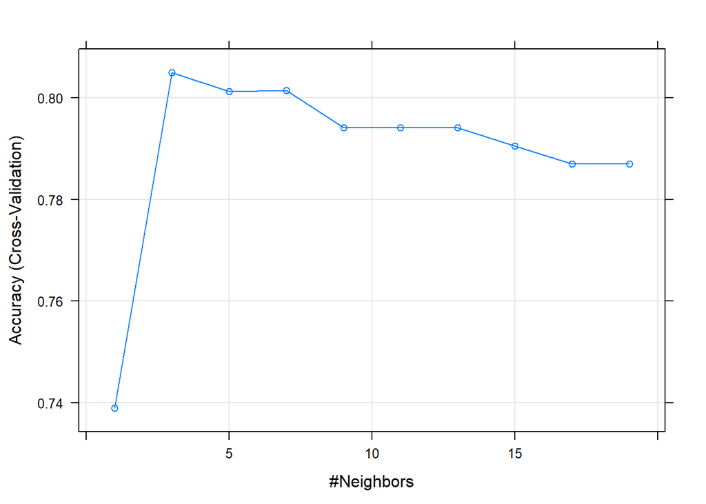

```r
ctrl <- trainControl(method = "cv", verboseIter = FALSE, number = 5)
knn_fit <- train(Diagnosis_Heart_Disease ~ .,
                data = train_heart_df, method = "knn", preProcess = c("center","scale"),
                trControl = ctrl , tuneGrid = expand.grid(k = seq(1, 20, 2)))

plot(knn_fit)
```

```r
knn_predict <- predict(knn_fit,newdata = test_heart_df )
knn_results <- confusionMatrix(knn_predict, test_heart_df$Diagnosis_Heart_Disease )

knn_results
```

```
## Confusion Matrix and Statistics
##
##           Reference
## Prediction  0  1
##          0  9  3
##          1  2 17
##
##                Accuracy : 0.8387
##                  95% CI : (0.6627, 0.9455)
##     No Information Rate : 0.6452
##     P-Value [Acc > NIR] : 0.01552
##
##                   Kappa : 0.6548
##
##  Mcnemar's Test P-Value : 1.00000
##
##             Sensitivity : 0.8182
##             Specificity : 0.8500
##          Pos Pred Value : 0.7500
##          Neg Pred Value : 0.8947
##              Prevalence : 0.3548
##          Detection Rate : 0.2903
##    Detection Prevalence : 0.3871
##       Balanced Accuracy : 0.8341
##
##        'Positive' Class : 0
##
```

```r
#Accuracy from the previous result
results_table <- results_table %>% add_row(Methods="KNN", Accuracy_of_Train_Sets= 0.8387  ,Accuracy_of_Test_Sets = 0.8387 )

#results_table
```

Support Vector Machine (SVM)  
SVM is a supervised machine learning algorithm which can be used for both classification or regression challenges. However, it is mostly used in classification problems.  
Support Vectors are simply the co-ordinates of individual observation. The SVM classifier is a frontier which best segregates the two classes (hyper-plane/ line).

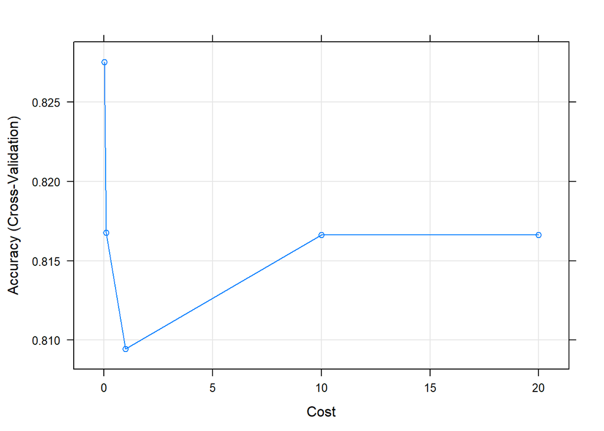

```r
ctrl <- trainControl(method = "cv", verboseIter = FALSE, number = 5)

grid_svm <- expand.grid(C = c(0.01, 0.1, 1, 10, 20))

svm_fit <- train(Diagnosis_Heart_Disease ~ ., data = train_heart_df, method = "svmLinear", preProcess = c("center","scale"), tuneGrid = grid_svm, trControl = ctrl)

plot(svm_fit)
```

```r
svm_predict <- predict(svm_fit, newdata = test_heart_df)
svm_results <- confusionMatrix(svm_predict, test_heart_df$Diagnosis_Heart_Disease)

svm_results
```

```
## Confusion Matrix and Statistics
##
##           Reference
## Prediction  0  1
##          0  8  2
##          1  3 18
##
##                Accuracy : 0.8387
##                  95% CI : (0.6627, 0.9455)
##     No Information Rate : 0.6452
##     P-Value [Acc > NIR] : 0.01552
##
##                   Kappa : 0.6404
##
##  Mcnemar's Test P-Value : 1.00000
##
##             Sensitivity : 0.7273
##             Specificity : 0.9000
##          Pos Pred Value : 0.8000
##          Neg Pred Value : 0.8571
##              Prevalence : 0.3548
##          Detection Rate : 0.2581
##    Detection Prevalence : 0.3226
##       Balanced Accuracy : 0.8136
##
##        'Positive' Class : 0
##
```

```r
#Accuracy from the previous result
results_table <- results_table %>% add_row(Methods="SVM", Accuracy_of_Train_Sets= 0.8387  ,Accuracy_of_Test_Sets = 0.8387 )

#results_table
```

Random Forest

Random forests are a very popular approach that address the shortcomings of decision trees using a clever idea.  
The goal is to improve prediction performance and reduce instability by averaging multiple decision trees, a forest of trees constructed with randomness.

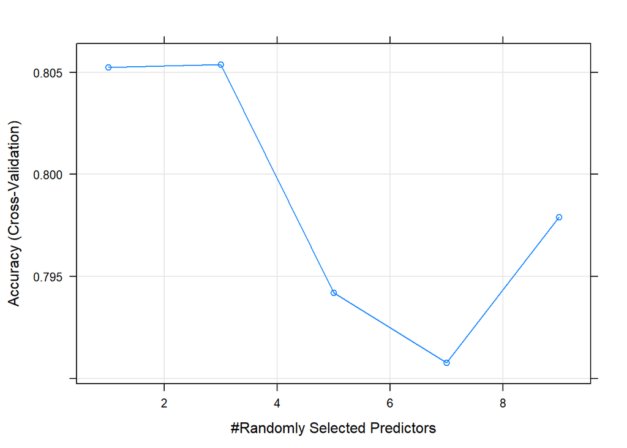

```r
control<- trainControl(method = "cv", number = 5, verboseIter = FALSE)
grid <-data.frame(mtry = seq(1, 10, 2))
rf_fit <- train(Diagnosis_Heart_Disease ~ ., method = "rf", data = train_heart_df, ntree = 20, trControl = control,
                  tuneGrid = grid)

plot(rf_fit)
```

```r
rf_predict <- predict(rf_fit, newdata = test_heart_df)

rf_results <- confusionMatrix(rf_predict, test_heart_df$Diagnosis_Heart_Disease)

rf_results
```

```
## Confusion Matrix and Statistics
##
##           Reference
## Prediction  0  1
##          0  8  2
##          1  3 18
##
##                Accuracy : 0.8387
##                  95% CI : (0.6627, 0.9455)
##     No Information Rate : 0.6452
##     P-Value [Acc > NIR] : 0.01552
##
##                   Kappa : 0.6404
##
##  Mcnemar's Test P-Value : 1.00000
##
##             Sensitivity : 0.7273
##             Specificity : 0.9000
##          Pos Pred Value : 0.8000
##          Neg Pred Value : 0.8571
##              Prevalence : 0.3548
##          Detection Rate : 0.2581
##    Detection Prevalence : 0.3226
##       Balanced Accuracy : 0.8136
##
##        'Positive' Class : 0
##
```

```r
#Accuracy from the previous result
results_table <- results_table %>% add_row(Methods="RF", Accuracy_of_Train_Sets= 0.8387  ,Accuracy_of_Test_Sets = 0.8387 )

#results_table
```

Gradient Boosting Machine (GBM)  
GBM constructs a forward stage-wise additive model by implementing gradient descent in function space.  
GBM build an ensemble of shallow and weak successive trees.

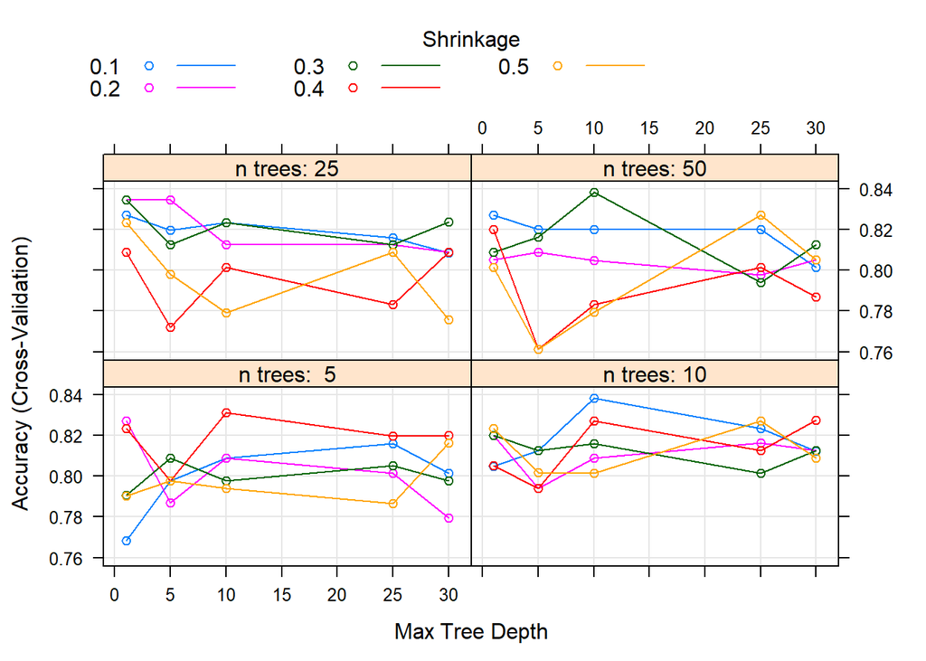

```r
gbmGrid <-  expand.grid(interaction.depth = c(1, 5, 10, 25, 30),n.trees = c(5, 10, 25, 50), shrinkage = c(0.1, 0.2, 0.3,  0.4, 0.5), n.minobsinnode = 20)

gbm_fit <- train(Diagnosis_Heart_Disease ~ ., method = "gbm", data = train_heart_df,  trControl = control, verbose = FALSE,tuneGrid = gbmGrid)

plot(gbm_fit)
```

```r
gbm_predict <- predict(gbm_fit, newdata = test_heart_df)

gbm_results <- confusionMatrix(gbm_predict, test_heart_df$Diagnosis_Heart_Disease)

gbm_results
```

```
## Confusion Matrix and Statistics
##
##           Reference
## Prediction  0  1
##          0  8  3
##          1  3 17
##
##                Accuracy : 0.8065
##                  95% CI : (0.6253, 0.9255)
##     No Information Rate : 0.6452
##     P-Value [Acc > NIR] : 0.04116
##
##                   Kappa : 0.5773
##
##  Mcnemar's Test P-Value : 1.00000
##
##             Sensitivity : 0.7273
##             Specificity : 0.8500
##          Pos Pred Value : 0.7273
##          Neg Pred Value : 0.8500
##              Prevalence : 0.3548
##          Detection Rate : 0.2581
##    Detection Prevalence : 0.3548
##       Balanced Accuracy : 0.7886
##
##        'Positive' Class : 0
##
```

```r
#Accuracy from the previous result
results_table <- results_table %>% add_row(Methods="GBM", Accuracy_of_Train_Sets= 0.8065  ,Accuracy_of_Test_Sets = 0.8065 )

#results_table
```

Results of the accuracy of the predictions

As we see the resulting table which shows the overall accuracy for each model we build, the model that gives us the higher accuracy is LDA model.

```r
#Print the final results table
results_table
```

```
##                     Methods Accuracy_of_Train_Sets Accuracy_of_Test_Sets
## 1 Logistic Regression Model              0.8602941             0.7419355
## 2     Regression Tree Model              0.8639706             0.6451613
## 3                       QDA              0.8065000             0.8065000
## 4                       LDA              0.9032000             0.9032000
## 5                       KNN              0.8387000             0.8387000
## 6                       SVM              0.8387000             0.8387000
## 7                        RF              0.8387000             0.8387000
## 8                       GBM              0.8065000             0.8065000
```

Conclusion

Future Work  
As a future plans more machine learning models would be built to find if we can get a higher rate of accuracy, also ensemble method should be considered to apply on such Data set, to combine the advantages of various models and enhance the overall performance of prediction.

References:

https://wanjirumaggie45.medium.com/data-science-for-good-machine-learning-for-heart-disease-prediction-289234651fed

https://archive.ics.uci.edu/ml/datasets/heart+disease

https://www.kaggle.com/rashikrahmanpritom/heart-attack-analysis-prediction-dataset

https://www.kaggle.com/tentotheminus9/what-causes-heart-disease-explaining-the-model

https://towardsdatascience.com/heart-disease-uci-diagnosis-prediction-b1943ee835a7

https://www.kaggle.com/ronitf/heart-disease-uci

https://www.r-bloggers.com/2019/09/heart-disease-prediction-from-patient-data-in-r/

https://www.kaggle.com/snogard/heart-disease-uci-using-r

https://www.kaggle.com/faressayah/predicting-heart-disease-using-machine-learning

https://towardsdatascience.com/heart-disease-prediction-73468d630cfc

https://towardsdatascience.com/predicting-presence-of-heart-diseases-using-machine-learning-36f00f3edb2c

https://towardsdatascience.com/boosting-algorithm-gbm-97737c63daa3

https://developers.google.com/machine-learning/crash-course/classification/roc-and-auc

https://en.wikipedia.org/wiki/Logistic_regression

https://www.analyticsvidhya.com/blog/2017/09/understaing-support-vector-machine-example-code/

https://rpubs.com/phamdinhkhanh/389752

http://www.cookbook-r.com/Graphs/Colors_(ggplot2)/

https://ggplot2.tidyverse.org/reference/scale_manual.html